# Pruebas de Hipótesis

Emanuel Mejía

```r
library(nortest)
library(EnvStats)
```

# 1 Pruebas de Normalidad

## 1.1 Anderson-Darling

A nivel general evalúa si los datos coinciden con una curva normal (campana) al medir la distancia al cuadrado entre la línea ajustada y los datos.

La prueba funciona como sigue:

- $H_0:$ Los datos siguen una distribución normal.
- $H_1:$ Los datos no siguen una distribución normal.
- Estadístico de prueba $A^2$: Entre más alto se tiene una diferencia más grande entre nuestros datos y una distribución normal.

El estadístico de prueba $A^2$ sigue una **distribución asintótica no estándar**. No coincide con distribuciones comunes. En realidad se trata de una suma infinita de distribuciones ponderadas $\chi^2$, por lo que requiere aproximaciones numéricas o tablas de valores críticos.

Si el p-value es menor que el nivel de significancia $\alpha$, se rechaza la hipótesis nula $H_0$ y se concluye que los datos no siguen una distribución normal.

## 1.2 Kolmogorov-Smirnov

Esta prueba es una herramienta estadística para verificar si los datos siguen una distribución teórica específica (como la normal). A nivel general evalúa si los datos coinciden con una distribución de referencia al medir la distancia máxima absoluta entre la función de distribución acumulada empírica de los datos y la teórica.

La prueba funciona como sigue:

- $H_0:$ Los datos siguen una distribución normal.
- $H_1:$ Los datos no siguen una distribución normal.
- Estadístico de prueba $D$: Entre más alto, se tiene una diferencia máxima más grande entre nuestros datos y una distribución normal.

El estadístico de prueba $D$ sigue la **distribución de Kolmogorov**. No coincide con distribuciones comunes. En realidad se deriva del valor máximo (supremo) de un proceso estocástico conocido como puente browniano, por lo que requiere aproximaciones numéricas o tablas de valores críticos específicas.

Si el p-value es menor que el nivel de significancia $\alpha$, se rechaza la hipótesis nula $H_0$ y se concluye que los datos no siguen una distribución normal.

La **Prueba de Lilliefors** modifica la prueba clásica de Kolmogorov-Smirnov permitiendo estimar la media y la varianza directamente de la muestra cuando estos valores son desconocidos.

# 2 Pruebas de Hipótesis

## 2.1 Media $\mu$ de una población normal

*Ejemplo*

Una empresa de botanas desea verificar si el proceso de llenado de las bolsas grandes de papas está operando correctamente. Cada 6 horas se toma una muestra aleatoria de 15 bolsas. Los últimos datos se muestran a continuación:

```r
papitas
```

```
##    gramos
## 1     992
## 2    1005
## 3     985
## 4    1007
## 5     996
## 6    1019
## 7     998
## 8     987
## 9     979
## 10    992
## 11    999
## 12   1007
## 13    982
## 14    973
## 15   1013
```

¿El proceso está llenando las bolsas correctamente si la etiqueta acusa 1kg de producto? Usa un nivel de significancia del 5%.

*Solución*

Para realizar esta prueba de hipótesis, primero se debe verificar la normalidad de los datos.

```r
adt <- ad.test(papitas$gramos)
adt
```

```
##
##  Anderson-Darling normality test
##
## data:  papitas$gramos
## A = 0.12515, p-value = 0.9809
```

Como el p-value de la prueba Anderson-Darling es 0.9809 y es mayor que el nivel de significancia del 5%, se puede asumir que la muestra proviene de una población normal.

Luego de haber explorado la normalidad, retornamos al problema de interés que se puede resumir así:

$$H_0: \mu = 1,000\text{ gr}$$
$$H_1: \mu \neq 1,000\text{ gr}$$

Procedemos a aplicar la prueba como sigue:

```r
phMeanPapas <- t.test(
  papitas$gramos,           # Vector numérico de datos
  mu=1000,                  # Media bajo H0
  alternative='two.sided',  # Tipo de H1 ("two.sided", "less", "greater")
  conf.level=0.95)          # Nivel de Confianza

phMeanPapas
```

```
##
##  One Sample t-test
##
## data:  papitas$gramos
## t = -1.3016, df = 14, p-value = 0.214
## alternative hypothesis: true mean is not equal to 1000
## 95 percent confidence interval:
##   988.3499 1002.8501
## sample estimates:
## mean of x
##     995.6
```

Como el p-value es 0.214 y es mayor que el nivel de significancia del 5%, no se rechaza la hipótesis nula ($H_0$). Es decir, las evidencias no son suficientes para afirmar que el proceso de llenado no está cumpliendo con lo impreso en la envoltura.

## 2.2 Varianza $\sigma^2$ de una población normal

*Ejemplo* El proceso de llenado se considera que opera bajo la variabilidad permitida si presenta una varianza de 100 o menos. ¿Está el proceso bajo control en su variabilidad? Use un nivel de significancia del 5%.

*Solucion*

En este ejemplo nos interesa estudiar el siguiente conjunto de hipótesis:

$$H_0: \sigma^2 \le 100$$
$$H_1: \sigma^2 > 100$$

La prueba de hipótesis se puede realizar usando la función varTest de la librería EnvStats por medio del siguiente código:

```r
phVarPapas <- varTest(
  x = papitas$gramos,       # Vector numérico de datos
  sigma.squared = 100,    # Varianza bajo H0
  alternative='greater',  # Tipo de H1 ("two.sided", "less", "greater")
  conf.level=0.95)        # Nivel de Confianza

phVarPapas
```

```
## $statistic
## Chi-Squared
##      23.996
##
## $parameters
## df
## 14
##
## $p.value
## [1] 0.04587329
##
## $estimate
## variance
##    171.4
##
## $null.value
## variance
##      100
##
## $alternative
## [1] "greater"
##
## $method
## [1] "Chi-Squared Test on Variance"
##
## $data.name
## [1] "papitas$gramos"
##
## $conf.int
##     LCL     UCL
## 101.314     Inf
## attr(,"conf.level")
## [1] 0.95
##
## attr(,"class")
## [1] "htestEnvStats"
```

Como el p-value es 0.0459 y es menor que el nivel de significancia del 5%, se rechaza la hipótesis nula ($H_0$). Es decir, las evidencias son suficientes para afirmar que el proceso de llenado no está cumpliendo con la variabilidad permitida.

## 2.3 Cocientes de varianzas $\sigma^2_1 / \sigma^2_2$ de una población normal

*Ejemplo*

En un país se toma una muestra aleatoria de 20 niñas de 1 año y medio de edad provenientes de dos regiones distintas y se registran sus estaturas en milímetros. ¿Es diferente la varianza de las estaturas distinta en cada región?

Los datos se muestran a continuación:

```r
estaturas
```

```
##     R1  R2
## 1  740 651
## 2  808 738
## 3  740 650
## 4  750 689
## 5  819 741
## 6  800 734
## 7  771 701
## 8  827 751
## 9  804 739
## 10 765 701
## 11 758 689
## 12 822 746
## 13 740 660
## 14 850 770
## 15 778 707
## 16 750 679
## 17 765 678
## 18 850 769
## 19 784 723
## 20 850 770
```

*Solución*

En este problema interesa probar si las varianzas poblacionales son iguales o no. Por esta razón, el cociente $\sigma^2_{R1} / \sigma^2_{R2}$ se iguala al valor de 1, que será el valor de referencia de la prueba.

$$H_0: \frac{\sigma^2_{R1}}{\sigma^2_{R2}}
= 1$$
$$H_1:
\frac{\sigma^2_{R1}}{\sigma^2_{R2}} \neq 1$$
Primero se debe explorar si las muestras provienen de una población normal, para lo cual aplicaremos una prueba formal de normalidad a cada una de las muestras:

```r
ksR1 <- lillie.test(estaturas$R1)
ksR1
```

```
##
##  Lilliefors (Kolmogorov-Smirnov) normality test
##
## data:  estaturas$R1
## D = 0.12976, p-value = 0.5072
```

```r
ksR2 <- lillie.test(estaturas$R2)
ksR2
```

```
##
##  Lilliefors (Kolmogorov-Smirnov) normality test
##
## data:  estaturas$R2
## D = 0.14223, p-value = 0.3593
```

Los p-value de la prueba Kolmogorov-Smirnov 0.5072 para la región 1 y 0.3593 para la región 2 nos permiten asumir que las poblaciones son normales, por lo que podemos continuar con nuestra prueba de hipótesis inicial. Para realizar este tipo de prueba se usa la función var.test

```r
varEstaturas <- var.test(
  x=estaturas$R1,            # Vector numérico 1
  y=estaturas$R2,            # Vector numérico 2
  ratio=1,                   # Ratio bajo H0
  alternative="two.sided",   # Tipo de H1 ("two.sided", "less", "greater")
  conf.level=0.95)           # Nivel de confianza

varEstaturas
```

```
##
##  F test to compare two variances
##
## data:  estaturas$R1 and estaturas$R2
## F = 0.96199, num df = 19, denom df = 19, p-value = 0.9336
## alternative hypothesis: true ratio of variances is not equal to 1
## 95 percent confidence interval:
##  0.3807686 2.4304287
## sample estimates:
## ratio of variances
##          0.9619932
```

Como el p-value es 0.9336, muy superior al nivel de significancia $\alpha = 0.05$, se puede concluir que las varianzas son similares.

## 2.4 Diferencia de medias $\mu_1 - \mu_2$

*Ejemplo*

En el país del ejemplo anterior se tiene la sospecha de que las niñas de la primera región tienen una menor estatura promedio que las niñas de la segunda.

¿Existen diferencias entre las estaturas promedio de ambas regiones? Usar un nivel de significancia $\alpha = 0.03$

*Solución*

Primero se construirá un boxplot comparativo para las estaturas de cada región.

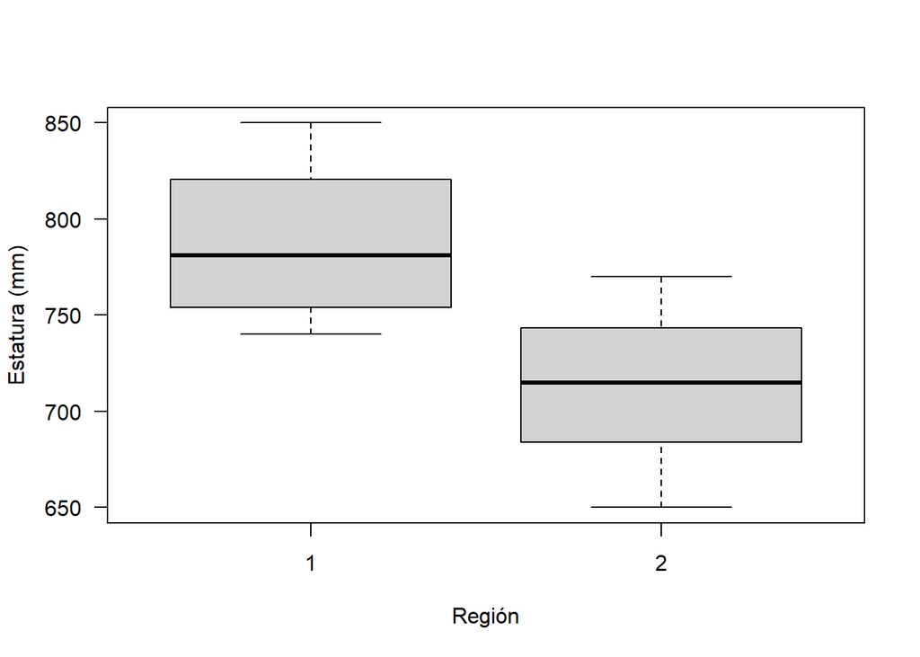

```r
datos <- data.frame(estatura=c(estaturas$R1, estaturas$R2),
                    region=rep(1:2, each=20))
boxplot(estatura ~ region, data=datos, las=1,
        xlab='Región', ylab='Estatura (mm)')
```

En esta figura podemos observar que las cajas no se traslapan, lo cual puede ser un indicio de que las medias poblacionales, $\mu_R1$ y $\mu_R2$, son diferentes. Y aparentemente las estaturas de $R_1$ están por encima de las de $R_2$.

En este problema interesa estudiar el siguiente conjunto de hipótesis:

$$H_0: \mu_1 - \mu_2 = 0$$
$$H_1: \mu_1 - \mu_2 \neq 0$$
Lo reaizaremos como sigue:

```r
phMeanEstatura <- t.test(
  x=estaturas$R1,           # Vector numérico 1
  y=estaturas$R2,           # Vector numérico 2
  mu=0,                     # Media bajo H0
  alternative="two.sided",  # Tipo de H1 ("two.sided", "less", "greater")
  paired=FALSE,             # Muestra pareada
  var.equal=TRUE,           # Varianza igual entre ambos vectores
  conf.level=0.97)          # Nivel de confianza

phMeanEstatura
```

```
##
##  Two Sample t-test
##
## data:  estaturas$R1 and estaturas$R2
## t = 6.0432, df = 38, p-value = 4.967e-07
## alternative hypothesis: true difference in means is not equal to 0
## 97 percent confidence interval:
##   46.54801 101.95199
## sample estimates:
## mean of x mean of y
##    788.55    714.30
```

De la prueba se obtiene un p-value muy pequeño, por lo tanto, podemos rechazar $H_0$ y concluir que si hay diferencias significativas entre las estaturas de ambas regiones, confirmando lo observado en el boxplot.

## 2.5 Proporción $p$

Para estudiar la proporción $p$ de una distribución binomial existen diversas pruebas. Una de ellas es la prueba binomial exacta.

*Ejemplo*

Una empresa de entregas en la ciudad asegura que el 90% de sus órdenes se entregan dentro de las siguientes 24 horas después de recolectado el producto. En una muestra de 500 órdenes, 440 se entregaron dentro de ese lapso. ¿Puede concluirse, con un nivel de significancia $\alpha = 0.05$, que menos del 90% de las órdenes se entregan en menos de 24 horas?

*Solución*

En este problema interesa probar lo siguiente:

$$H_0: p = 0.90$$
$$H_1: p < 0.90$$

```r
phEntrega <- binom.test(
  x=440,                # Número de éxitos
  n=500,                # Número de ensayos
  p=0.9,                # Proporción bajo H0
  alternative="less",   # Tipo de H1 ("two.sided", "less", "greater")
  conf.level=0.95       # Nivel de confianza
  )

phEntrega
```

```
##
##  Exact binomial test
##
## data:  440 and 500
## number of successes = 440, number of trials = 500, p-value = 0.08099
## alternative hypothesis: true probability of success is less than 0.9
## 95 percent confidence interval:
##  0.0000000 0.9031845
## sample estimates:
## probability of success
##                   0.88
```

El p-value es 0.081 y en este caso es mayor que $\alpha = 0.05$, por lo tanto se concluye que no hay evidencias suficientes para rechazar la hipótesis nula ($H_0$) a un nivel de significancia del $5$%.